# Pairwise enrichment: OD vs CTRL across osteogenic differentiation

Fetal (fMSC) and adult (aMSC) time courses, D1-D17

# 1 Setup

## 1.1 Libraries

Load order matters. Annotation and Bioconductor packages come first, and the tidyverse comes **last**, so that `dplyr::select`, `filter` and `rename` are not masked by `AnnotationDbi::select` or `biomaRt::select`. The original notebook achieved the same thing by calling `library(dplyr)` a second time at the end of the block; ordering makes the intent explicit instead.

```r
# --- project / environment -----------------------------------------------
library(renv)          # project library management (activated via .Rprofile)
library(here)          # paths relative to the project root

# --- annotation and differential expression ------------------------------
library(DESeq2)        # count modelling, lfcShrink
library(ashr)          # shrinkage estimator used by lfcShrink(type = "ashr")
library(org.Hs.eg.db)  # Ensembl -> symbol mapping
library(biomaRt)       # gene biotype lookup (protein-coding filter)
library(gprofiler2)    # GO / KEGG / Reactome / WikiPathways enrichment

# --- plotting -------------------------------------------------------------
library(ComplexHeatmap) # theme heatmaps
library(circlize)       # colorRamp2 for heatmap colour scales
library(EnhancedVolcano)# volcano plots
library(egg)            # ggarrange for side-by-side panels
library(svglite)        # vector output

# --- data handling and export --------------------------------------------
library(openxlsx)       # write.xlsx
library(tidyverse)      # ggplot2, dplyr, tidyr, stringr - loaded LAST (see above)

# plyr is used inside summarise_counts() via plyr::ddply and plyr::rename.
# It is deliberately NOT attached: attaching plyr after dplyr masks
# dplyr::rename / summarise and silently changes behaviour elsewhere.

# Removed relative to the original setup chunk:
#   library(ggplot2)  duplicate - part of tidyverse
#   library(dplyr)    duplicate - part of tidyverse (masking handled by order)
#   library(gdata)    no gdata function is called anywhere in this notebook
#   library(stringr)  was re-loaded twice mid-notebook - part of tidyverse
#   library(tidyr)    was re-loaded mid-notebook - part of tidyverse
```

## 1.2 Output helper

Every figure is written through `exportplots()` so that size and destination are handled in one place. `y` is a path relative to `OUTPUT_DIR`, without extension; prefix it with `patent/` to route a greyscale version to the print folder. The helper creates the destination folder itself, because `svglite()` does not and fails with `cannot open stream ...` when it is missing.

```r
# Single place to change where figures go. Set it to "output", "output_clean2",
# or anything else; nothing downstream needs editing.
OUTPUT_DIR <- "output_clean2"

exportplots <- function(x, y, w, h){
  y <- as.character(y)
  path <- here::here(OUTPUT_DIR, paste0(y, ".svg"))

  # svglite() will NOT create missing folders - it fails with
  #   "cannot open stream <path>"
  # Create the target folder first so that a new OUTPUT_DIR, or a filename
  # carrying a subfolder prefix such as "patent/...", just works.
  dir.create(dirname(path), recursive = TRUE, showWarnings = FALSE)

  svglite(filename = path, width = w, height = h)
  on.exit(dev.off(), add = TRUE)   # close the device even if print(x) errors,
                                   # otherwise every later plot lands in the
                                   # half-written SVG
  print(x)
  invisible(path)
}

# Destinations used by name elsewhere in the notebook.
dir.create(here::here(OUTPUT_DIR, "patent"), recursive = TRUE, showWarnings = FALSE)
```

## 1.3 Shared constants

```r
# Timepoint ordering used for every factor and every plot axis.
TIME_LEVELS <- c("D0", "D1", "D2", "D3", "D4", "D10", "D17")

# Contrasts are OD vs CTRL at each timepoint except D0 (baseline, no OD arm).
CONTRAST_DAYS <- c("D1", "D2", "D3", "D4", "D10", "D17")

# Significance thresholds used throughout for calling a gene differential.
LFC_CUT  <- 1     # |log2 fold change|
PADJ_CUT <- 0.01  # adjusted p value

# Column positions in a gprofiler2 gost() result, referred to by name below:
#   3 = p_value, 9 = term_id, 11 = term_name
```

# 2 Helper functions

All functions live here, defined exactly once. In the original notebook several of these were defined twice — once in colour and once in greyscale, and in two cases under the *same* name, so the second definition silently replaced the first. Each function below takes a `greyscale` argument instead.

## 2.1 Theme heatmap across timepoints

Builds a pathway (rows) by timepoint (columns) matrix of adjusted p values for two enrichment sets side by side — for example fMSC OD next to fMSC CTRL, or fMSC OD next to aMSC OD. Cells with no enrichment stay at 1 and pathways that are never enriched in either set are dropped.

```r
plot_theme_heatmap <- function(GeneList, Matrix, Matrix2, HmapTitle, FileName,
                               greyscale = FALSE,
                               block_labels = c("A", "B"),
                               cell_h = 0.5,   # cm per pathway row
                               body_w = 8){    # cm per block

  # Blank matrix, one row per pathway and one column per timepoint.
  # 1 = "not enriched", which is also the top of the colour scale.
  blank <- data.frame(x1 = sort(GeneList),
                      D1 = 1, D2 = 1, D3 = 1, D4 = 1, D10 = 1, D17 = 1)
  GeneList_Matrix  <- blank
  GeneList_Matrix2 <- blank

  # Fill in the adjusted p value (gost result column 3) for every pathway that
  # was enriched at that timepoint. x + 1 skips the pathway-name column.
  for (x in 1:length(Matrix)) {
    for (i in which(Matrix[[x]]$term_name %in% GeneList)) {
      GeneList_Matrix[which(GeneList_Matrix$x1 == Matrix[[x]]$term_name[i]), x + 1] <-
        Matrix[[x]][i, 3]
    }
  }
  for (x in 1:length(Matrix2)) {
    for (i in which(Matrix2[[x]]$term_name %in% GeneList)) {
      GeneList_Matrix2[which(GeneList_Matrix2$x1 == Matrix2[[x]]$term_name[i]), x + 1] <-
        Matrix2[[x]][i, 3]
    }
  }

  # Concatenate the two sets horizontally: block A then block B.
  all(GeneList_Matrix$x1 %in% GeneList_Matrix2$x1)  # sanity check, same rows/order
  plot <- cbind(GeneList_Matrix, GeneList_Matrix2[, -1])

  # Pathway names become rownames; the rest becomes a numeric matrix.
  rownames(plot) <- plot$x1
  plot <- plot[, -1]
  plot <- data.matrix(plot)

  # Drop pathways that are at 1 everywhere (never enriched in either block).
  plot <- plot[rowSums(plot != 1) > 0, , drop = FALSE]

  n <- nrow(plot)
  if (n == 0) {
    message("plot_theme_heatmap: no enriched pathways for '", HmapTitle,
            "' - nothing plotted.")
    return(invisible(NULL))
  }

  # --- canvas sizing ------------------------------------------------------
  # The heatmap body is nrow * cell_h tall, so a fixed 15 x 30 inch canvas
  # leaves a one-row theme (immune) as a sliver in a sea of whitespace. Size
  # the canvas from the content instead, with sane floors and ceilings.
  rowname_cm <- max(nchar(rownames(plot))) * 0.17   # ~0.17 cm per char at fontsize 10
  h_in <- min(max((n * cell_h + 5.5) / 2.54, 3), 40)
  w_in <- min(max((2 * body_w + 0.5 + rowname_cm + 4) / 2.54, 6), 25)

  # Shrink the title with the figure; 25pt on a 3-inch canvas overlaps the plot.
  title_size <- max(10, min(25, round(h_in * 2.2)))

  # Colour scale: significant -> dark, non-significant -> white.
  col_hmap <- if (greyscale) {
    colorRamp2(c(0, 0.05, 1), c("black", "gray70", "white"))
  } else {
    colorRamp2(c(0, 0.05, 1), c("red", "pink", "white"))
  }

  # cbind() made the second block's names unique (D1.1, D2.1, ...). Relabel so
  # both blocks read D1..D17, and name the blocks themselves instead.
  col_labels <- rep(CONTRAST_DAYS, 2)
  col_split  <- factor(rep(block_labels, each = 6), levels = block_labels)

  Enrichment_Heatmap <- Heatmap(
    plot,
    show_column_dend  = FALSE,
    show_row_names    = TRUE,
    show_row_dend     = n > 1,
    cluster_columns   = FALSE,
    cluster_rows      = n > 1,          # hclust needs at least two rows
    column_labels     = col_labels,
    column_split      = col_split,      # the two enrichment sets
    column_gap        = unit(5, "mm"),
    name              = "Adjusted-P Value",
    column_title      = HmapTitle,
    column_title_gp   = gpar(fontsize = title_size, fontface = "bold"),
    row_names_gp      = gpar(fontsize = 10),
    col               = col_hmap,
    width             = unit(body_w, "cm"),
    height            = unit(n * cell_h, "cm"),   # grows with pathway count
    heatmap_legend_param = list(at = c(0, 0.01, 0.02, 0.03, 0.04, 0.05))
  )
  Enrichment_Heatmap <- draw(Enrichment_Heatmap, heatmap_legend_side = "left")

  exportplots(x = Enrichment_Heatmap,
              y = if (greyscale) paste0(FileName, "_greyscale") else FileName,
              h = h_in, w = w_in)

  invisible(c(pathways = n, height_in = h_in, width_in = w_in))
}

# Backwards-compatible names, in case other scripts call the old ones.
plot_2matrix_GSEA_hmap <- function(...)
  plot_theme_heatmap(..., greyscale = FALSE)
plot_2matrix_GSEA_hmap_greyscale <- function(...)
  plot_theme_heatmap(..., greyscale = TRUE)
```

## 2.2 GO enrichment per timepoint

One call per timepoint, querying the genes that pass the fold-change and adjusted p thresholds in the requested direction: `"up"` = enriched in OD, `"down"` = enriched in CTRL. Timepoints that return nothing keep a `NULL` slot so the list stays aligned with `CONTRAST_DAYS`.

```r
run_gost_pairwise <- function(res_list, direction = c("up", "down"),
                              skip = integer(0), sources = "GO:BP"){
  direction <- match.arg(direction)
  out <- vector("list", length(res_list))

  for (i in seq_along(res_list)) {
    if (i %in% skip) next          # e.g. D1 CTRL, which has too few genes

    res  <- res_list[[i]]
    hits <- if (direction == "up") {
      res$EnsemblID[res$log2FoldChange >  LFC_CUT & res$padj < PADJ_CUT]
    } else {
      res$EnsemblID[res$log2FoldChange < -LFC_CUT & res$padj < PADJ_CUT]
    }

    # tryCatch returns NULL on failure. Single-bracket assignment of a
    # one-element list keeps the NULL slot instead of deleting it, which would
    # shift every later timepoint by one.
    out[i] <- list(tryCatch(
      gost(query = hits,
           organism = "hsapiens", ordered_query = FALSE,
           multi_query = FALSE, significant = TRUE, exclude_iea = FALSE,
           measure_underrepresentation = FALSE, evcodes = TRUE,
           user_threshold = 0.05, correction_method = "g_SCS",
           domain_scope = "annotated", custom_bg = NULL,
           numeric_ns = "", as_short_link = FALSE, highlight = TRUE,
           sources = sources)$result,
      error = function(e) NULL))
  }
  out
}
```

## 2.3 Grouping GO terms into themes

Scans every enrichment table for term names matching a set of keywords and returns the unique pathway names per theme. These become the rows of the heatmaps in section 6.

```r
# Two keywords in the original patterns never matched anything, which is why
# the immune theme collapsed to a single row:
#   "defence"    - GO term names use American spelling. Of the 31 GO terms
#                  QuickGO returns for "defence", none contain that string and
#                  29 contain "defense". Fixed below.
#   "homeotasis" - typo for "homeostasis". Fixed below. Low impact in practice,
#                  because "process" in the same pattern matches almost every
#                  GO:BP term anyway.
# Both fixes only ADD rows to the heatmaps. If you need to reproduce a figure
# made before this change, restore the two original spellings.
THEME_PATTERNS <- list(
  bone       = "bone|skele|collagen|matrix|osteo|oss",
  diff       = "diff|genesis|genic",
  immune     = "anti|immune|defense",
  secretion  = "secret|exoc|vesicle",
  metabolism = "homeostasis|metabolism|lysis|process|oxida|reduc"
)

# Broader immune vocabulary. GO:BP splits immune biology across several word
# stems that "immune" alone misses ("adaptive immunity", "inflammatory
# response", "cytokine-mediated signaling pathway"). Swap this in if the immune
# panel is still too sparse - it widens what counts as the immune theme, so say
# so in the methods if you use it.
IMMUNE_BROAD <- "anti|immun|defense|inflamm|cytokine|interleukin|chemokine|leukocyte"
# THEME_PATTERNS$immune <- IMMUNE_BROAD

collect_theme_terms <- function(..., patterns = THEME_PATTERNS){
  gsea_sets <- list(...)   # any number of enrichment lists, pooled together
  lapply(patterns, function(p) {
    terms <- character(0)
    for (gsea in gsea_sets) {
      for (tbl in gsea) {
        if (is.null(tbl)) next
        # column 11 = term_name
        terms <- unique(c(terms, tbl[which(grepl(p, tbl$term_name)), 11]))
      }
    }
    terms
  })
}
```

## 2.4 Volcano plot

```r
plot_de_volcano <- function(res, title = "DEGs at D4", greyscale = FALSE,
                            n_label = 15, max_overlaps = 15){

  res <- data.frame(res)
  res_reorder <- res[order(res$padj, decreasing = FALSE), ]   # most significant first

  # Three-way colour key: up in OD, up in CTRL, not significant.
  up   <- if (greyscale) "black"  else "red"
  down <- if (greyscale) "gray50" else "blue"
  ns   <- if (greyscale) "gray85" else "black"

  keyvals.colour <- ifelse(
    res$log2FoldChange < -LFC_CUT & res$padj < PADJ_CUT, down,
    ifelse(res$log2FoldChange > LFC_CUT & res$padj < PADJ_CUT, up, ns))
  keyvals.colour[is.na(keyvals.colour)] <- ns
  names(keyvals.colour)[keyvals.colour == down] <- "CTRL"
  names(keyvals.colour)[keyvals.colour == ns]   <- "N.S"
  names(keyvals.colour)[keyvals.colour == up]   <- "OD"

  EnhancedVolcano(res,
                  x = "log2FoldChange", y = "padj",
                  lab = res$Symbol,
                  selectLab = res_reorder$Symbol[1:n_label],
                  drawConnectors = TRUE, max.overlaps = max_overlaps,
                  pCutoff = PADJ_CUT, FCcutoff = LFC_CUT,
                  title = title,
                  pointSize = 2.0, colAlpha = 1, colCustom = keyvals.colour,
                  gridlines.major = FALSE, gridlines.minor = FALSE,
                  xlab = "Log2 Fold Change", ylab = "-log10(padj)")
}

# How many genes pass threshold in each direction - printed next to each volcano.
count_degs <- function(res){
  res <- data.frame(res)
  c(OD   = sum(res$log2FoldChange >  LFC_CUT & res$padj < PADJ_CUT, na.rm = TRUE),
    CTRL = sum(res$log2FoldChange < -LFC_CUT & res$padj < PADJ_CUT, na.rm = TRUE))
}
```

## 2.5 Pathway (Manhattan) plot

`run_gost_pathways()` queries KEGG, Reactome and WikiPathways for the genes up in OD; `plot_gost_manhattan()` renders the plot with a numbered table of highlighted terms underneath.

```r
run_gost_pathways <- function(res){
  res <- data.frame(res)
  gost(query = res$EnsemblID[res$log2FoldChange > LFC_CUT & res$padj < PADJ_CUT],
       ordered_query = FALSE, organism = "hsapiens", significant = TRUE,
       user_threshold = 0.05, correction_method = "fdr", exclude_iea = FALSE,
       sources = c("KEGG", "REAC", "WP"))
}

plot_gost_manhattan <- function(gostres, highlight_rows, greyscale = FALSE,
                                width = 10, height = 10, filename = NULL){

  p <- gostplot(gostres, capped = FALSE, interactive = FALSE)

  if (greyscale) {
    # One grey level per source. unique(gostres$result$source) confirms which
    # sources are present - all of them must be mapped or the plot errors.
    p <- p + scale_color_manual(values = c(KEGG = "black",
                                           REAC = "gray50",
                                           WP   = "gray80"))
    # Wrap long pathway names so the table underneath does not truncate them.
    gostres$result$term_name <- str_wrap(gostres$result$term_name, width = 40)
  }

  # Column 9 = term_id: which terms get numbered and tabulated.
  publish_gostplot(p, highlight_terms = gostres$result[highlight_rows, 9],
                   width = width, height = height, filename = filename)
}
```

## 2.6 Normalised counts for single genes

Three related plots, kept as separate functions because they answer different questions. In the original notebook the last two shared a name, so the mean +/- SD version was overwritten before it was ever called.

| function | x axis | shows |
| --- | --- | --- |
| `plot_gene_D4_counts()` | Condition, D4 only | one line per donor |
| `plot_gene_timecourse_mean()` | all timepoints | group mean +/- SD |
| `plot_gene_timecourse_donors()` | all timepoints | one line per donor and arm |

All three put fetal and adult side by side on a shared y axis and locate the gene by symbol via the D4 result table.

Note, carried over unchanged from the original: each panel adds `scale_y_log10()` and then `scale_y_continuous(limits = ...)`. ggplot keeps only the last y scale, so the axis is **linear**, not log, and knitting prints a “Scale for y is already present” message. Delete the `scale_y_log10()` line if a log axis was intended.

```r
# Group means and SDs. plyr is namespaced rather than attached so it cannot
# mask dplyr::rename / dplyr::summarise later in the notebook.
summarise_counts <- function(data, varname, groupnames){
  summary_func <- function(x, col) c(mean = mean(x[[col]], na.rm = TRUE),
                                     sd   = sd(x[[col]],   na.rm = TRUE))
  data_sum <- plyr::ddply(data, groupnames, .fun = summary_func, varname)
  plyr::rename(data_sum, c("mean" = varname))
}

# Ensembl ID of a gene symbol, taken from the D4 result table of that cohort.
gene_id_for <- function(res_D4, Gene) rownames(res_D4)[which(res_D4$Symbol == Gene)]

# Common y limit so the fetal and adult panels are directly comparable.
shared_ylim <- function(f_counts, a_counts)
  c(0, max(f_counts$count, a_counts$count * 1.1))
```

```r
plot_gene_D4_counts <- function(Gene, greyscale = FALSE){

  f.geneCounts <- plotCounts(f.d4.dds, gene = gene_id_for(f.pair.res[[4]], Gene),
                             intgroup = c("Condition", "Donor"), returnData = TRUE)
  a.geneCounts <- plotCounts(a.d4.dds, gene = gene_id_for(a.pair.res[[4]], Gene),
                             intgroup = c("Condition", "Donor"), returnData = TRUE)
  ylim <- shared_ylim(f.geneCounts, a.geneCounts)

  panel <- function(df, label){
    if (greyscale) {
      # Donor encoded by point shape and line type instead of colour.
      p <- ggplot(df, aes(x = Condition, y = count,
                          shape = Donor, linetype = Donor, group = Donor)) +
        geom_point(size = 2, color = "black") + geom_line(color = "black")
    } else {
      p <- ggplot(df, aes(x = Condition, y = count, colour = Donor, group = Donor)) +
        geom_point(size = 2) + geom_line()
    }
    p + scale_y_log10() + theme_classic() +
      ggtitle(paste(label, Gene)) + ylab("Normalized Counts") +
      scale_y_continuous(limits = ylim) +
      theme(legend.position = "bottom")
  }

  out <- ggarrange(panel(f.geneCounts, "Fetal"), panel(a.geneCounts, "Adult"), ncol = 2)
  exportplots(x = out,
              y = if (greyscale) paste0("patent/", Gene, "_greyscale") else Gene,
              h = 4, w = 7)
}
```

```r
plot_gene_timecourse_mean <- function(Gene, greyscale = FALSE){

  f.geneCounts <- plotCounts(pair[[1]], gene = gene_id_for(f.pair.res[[4]], Gene),
                             intgroup = c("Time", "Condition"), returnData = TRUE)
  a.geneCounts <- plotCounts(pair[[2]], gene = gene_id_for(a.pair.res[[4]], Gene),
                             intgroup = c("Time", "Condition"), returnData = TRUE)

  f <- summarise_counts(f.geneCounts, varname = "count",
                        groupnames = c("Time", "Condition"))
  a <- summarise_counts(a.geneCounts, varname = "count",
                        groupnames = c("Time", "Condition"))

  ylim <- shared_ylim(f.geneCounts, a.geneCounts)
  pd   <- position_dodge(0.5)   # separate OD and CTRL at each timepoint

  panel <- function(df, label){
    aes_base <- if (greyscale) {
      aes(x = Time, y = count, shape = Condition, group = Condition)
    } else {
      aes(x = Time, y = count, color = Condition, group = Condition)
    }
    p <- ggplot(df, aes_base)
    p <- if (greyscale) {
      p + geom_point(position = pd, size = 4, color = "black") +
        scale_shape_manual(values = c(16, 17))                 # circle, triangle
    } else {
      p + geom_point(position = pd, size = 4) +
        scale_color_manual(values = c("lightblue", "magenta"))
    }
    p + scale_y_log10() + theme_classic() +
      ggtitle(paste0(label, " ", Gene)) + ylab("Normalized Counts") +
      scale_y_continuous(limits = ylim) +
      theme(axis.text.x = element_text(size = 7),
            axis.text.y = element_text(size = 7),
            legend.position = "bottom") +
      # Error bars are clipped to the panel so they cannot rescale the axis.
      geom_errorbar(aes(ymax = pmin(count + sd, ylim[2]),
                        ymin = pmax(count - sd, 0)),
                    width = 0.2, color = "black", position = pd)
  }

  out <- ggarrange(panel(f, "Fetal"), panel(a, "Adult"), ncol = 2)
  exportplots(x = out,
              y = if (greyscale) paste0("patent/8_", Gene, "_greyscale") else Gene,
              h = 4, w = 6)
}
```

```r
plot_gene_timecourse_donors <- function(Gene, greyscale = TRUE){

  f.geneCounts <- plotCounts(pair[[1]], gene = gene_id_for(f.pair.res[[4]], Gene),
                             intgroup = c("Time", "Condition", "Donor"), returnData = TRUE)
  a.geneCounts <- plotCounts(pair[[2]], gene = gene_id_for(a.pair.res[[4]], Gene),
                             intgroup = c("Time", "Condition", "Donor"), returnData = TRUE)

  ylim <- shared_ylim(f.geneCounts, a.geneCounts)
  pd   <- position_dodge(0.5)

  panel <- function(df, label){
    # One trace per donor x condition; condition carried by shape and linetype.
    ggplot(df, aes(x = Time, y = count, shape = Condition, linetype = Condition,
                   group = interaction(Donor, Condition))) +
      scale_y_log10() +
      geom_point(position = pd, size = 3, color = "black") +
      geom_line(position = pd, color = "black") +
      theme_classic() +
      ggtitle(paste0(label, " ", Gene)) + ylab("Normalized Counts") +
      scale_shape_manual(values = c(16, 17)) +
      scale_y_continuous(limits = ylim) +
      theme(axis.text.x = element_text(size = 7),
            axis.text.y = element_text(size = 7),
            legend.position = "bottom")
  }

  out <- ggarrange(panel(f.geneCounts, "Fetal"), panel(a.geneCounts, "Adult"), ncol = 2)
  exportplots(x = out, y = paste0(Gene, "_greyscale_alldonors"), h = 4, w = 6)
}
```

```r
plot_gost_dotplot <- function(gostres, rows = NULL, n_top = 12,
                              greyscale = FALSE,
                              title     = NULL,
                              wrap      = 45,
                              cell_h    = 0.55){   # cm per pathway row

  df <- gostres$result

  # ---- which terms to show ------------------------------------------------
  if (is.null(rows)) {
    # Top n_top per source, by adjusted p value.
    df <- do.call(rbind, lapply(split(df, df$source), function(d)
      d[order(d$p_value), ][seq_len(min(n_top, nrow(d))), , drop = FALSE]))
  } else {
    df <- df[rows, , drop = FALSE]
  }
  df <- df[!is.na(df$term_name), , drop = FALSE]

  if (!nrow(df)) {
    message("plot_gost_dotplot: no terms to plot.")
    return(invisible(NULL))
  }

  # ---- derived quantities -------------------------------------------------
  # precision = intersection_size / query_size, i.e. the usual "gene ratio".
  df$gene_ratio <- if ("precision" %in% names(df)) df$precision
                   else df$intersection_size / df$query_size
  df$neglog10p  <- -log10(df$p_value)
  df$label      <- str_wrap(df$term_name, width = wrap)
  df$source     <- factor(df$source, levels = c("KEGG", "REAC", "WP"))

  # Order rows by gene ratio within each source facet. Making the factor
  # levels follow the global ordering keeps facets internally sorted.
  df <- df[order(df$source, df$gene_ratio), ]
  df$label <- factor(df$label, levels = unique(df$label))

  # ---- canvas sized to content -------------------------------------------
  n_lines <- sum(vapply(strsplit(levels(df$label), "\n"), length, integer(1)))
  h_in <- min(max((n_lines * cell_h + 4) / 2.54, 4), 40)
  w_in <- min(max((wrap * 0.17 + 12) / 2.54, 7), 20)

  col_scale <- if (greyscale) {
    scale_colour_gradient(low = "grey80", high = "black",
                          name = expression(-log[10]~italic(p)))
  } else {
    scale_colour_gradient(low = "pink", high = "red",
                          name = expression(-log[10]~italic(p)))
  }

  p <- ggplot(df, aes(x = gene_ratio, y = label)) +
    geom_point(aes(size = intersection_size, colour = neglog10p)) +
    col_scale +
    scale_size_continuous(range = c(2, 7), name = "Genes in term") +
    facet_grid(rows = vars(source), scales = "free_y", space = "free_y") +
    labs(title = title, x = "Gene ratio (intersection / query)", y = NULL) +
    theme_bw(base_size = 11) +
    theme(plot.title       = element_text(face = "bold", hjust = 0.5),
          strip.background = element_rect(fill = if (greyscale) "grey90" else "grey95"),
          strip.text       = element_text(face = "bold"),
          panel.grid.minor = element_blank(),
          axis.text.y      = element_text(size = 9),
          legend.position  = "right")

  attr(p, "size_in") <- c(h = h_in, w = w_in)   # so the caller can size output
  p
}
```

# 3 Data

## 3.1 Import counts and metadata

Both cohorts are held in parallel lists, `counts[[1]]`/`meta[[1]]` = fetal and `counts[[2]]`/`meta[[2]]` = adult, so every downstream loop runs over both.

```r
# Fetal MSC
f.counts <- read.csv(here("data", "fMSC_norm_counts.csv"), row.names = 1)
f.meta   <- read.csv(here("data", "fMSC_meta.csv"),        row.names = 1)

# Adult MSC
a.counts <- read.csv(here("data", "aMSC_norm_counts.csv"), row.names = 1)
a.meta   <- read.csv(here("data", "aMSC_meta.csv"),        row.names = 1)

counts <- list(fMSC = f.counts, aMSC = a.counts)
meta   <- list(fMSC = f.meta,   aMSC = a.meta)

# Timepoints are ordinal, not alphabetical - D10 must not sort before D2.
meta <- lapply(meta, function(m){
  m$Time <- factor(m$Time, levels = TIME_LEVELS)
  m
})
```

## 3.2 Restrict to protein-coding genes

Biotypes come from Ensembl via biomaRt. The mirror is pinned for reproducibility.

```r
mart <- useEnsembl(biomart = "genes",
                   dataset = "hsapiens_gene_ensembl",
                   mirror  = "useast")   # pinned mirror, safer for publication

coding.counts <- list()
for (i in 1:length(counts)) {
  annot <- getBM(attributes = c("ensembl_gene_id", "gene_biotype"),
                 filters    = "ensembl_gene_id",
                 values     = rownames(counts[[i]]),
                 mart       = mart)

  protein_coding_genes <- annot$ensembl_gene_id[annot$gene_biotype == "protein_coding"]
  coding.counts[[i]]   <- counts[[i]][rownames(counts[[i]]) %in% protein_coding_genes, ]
}
names(coding.counts) <- names(counts)

sapply(coding.counts, nrow)   # genes retained per cohort
```

```
 fMSC  aMSC
19980 19980
```

# 4 Differential expression

## 4.1 DESeq2 models

One model per cohort. `group` combines timepoint and condition into a single factor (`D4OD`, `D4CTRL`, …) so that any timepoint can be contrasted directly; `Donor` absorbs the paired design.

```r
pair <- list()

for (i in 1:length(counts)) {
  # Keep only libraries present in both the count matrix and the metadata,
  # in the same order.
  common_samples <- intersect(colnames(coding.counts[[i]]), rownames(meta[[i]]))
  counts_mat <- coding.counts[[i]][, common_samples]
  metadata   <- meta[[i]][common_samples, ]

  metadata$Time      <- factor(metadata$Time, levels = TIME_LEVELS)
  metadata$Condition <- factor(metadata$Condition)
  metadata$Donor     <- factor(metadata$Donor)

  # Built with design = ~ 1 so prefiltering happens before the real design.
  x <- DESeqDataSetFromMatrix(countData = round(counts_mat),
                              colData   = metadata,
                              design    = ~ 1)

  keep <- rowSums(counts(x) >= 10) >= 3     # 10+ counts in at least 3 libraries
  x    <- x[keep, ]

  x$group   <- factor(paste0(x$Time, x$Condition))
  design(x) <- ~ group + Donor

  pair[[i]] <- DESeq(x)
}
names(pair) <- names(counts)
```

## 4.2 Pairwise OD vs CTRL contrasts

`lfcShrink(type = "ashr", lfcThreshold = 1)` tests against a fold-change threshold rather than against zero, so `padj` already accounts for effect size.

```r
pairwise_OD_vs_CTRL <- function(dds, days = CONTRAST_DAYS){
  res <- lapply(days, function(d)
    lfcShrink(dds, contrast = c("group", paste0(d, "OD"), paste0(d, "CTRL")),
              type = "ashr", lfcThreshold = LFC_CUT))
  names(res) <- days

  # Carry the identifiers as columns so downstream code never has to rely on
  # column positions (the original used res[[i]][, 8] and [, 9]).
  lapply(res, function(r){
    r$EnsemblID <- rownames(r)
    r$Symbol    <- mapIds(org.Hs.eg.db, keys = r$EnsemblID,
                          keytype = "ENSEMBL", column = "SYMBOL")
    r
  })
}
```

```r
f.pair.res <- pairwise_OD_vs_CTRL(pair[[1]])

# The original passed rownames = TRUE, which openxlsx ignores (the argument is
# rowNames), so no row-name column was ever written. Kept that way on purpose -
# the identifiers are already in the EnsemblID column.
write.xlsx(f.pair.res, here(OUTPUT_DIR, "Fetal Pairwise Comparisons.xlsx"),
           colNames = TRUE, rowNames = FALSE)
```

```r
a.pair.res <- pairwise_OD_vs_CTRL(pair[[2]])

# The original wrote this file without an extension ("Adult Pairwise DEGs").
write.xlsx(a.pair.res, here(OUTPUT_DIR, "Adult Pairwise DEGs.xlsx"),
           colNames = TRUE, rowNames = FALSE)
```

# 5 GO enrichment

## 5.1 Per timepoint, per cohort

Genes up in OD and genes up in CTRL are queried separately against GO:BP. D1 CTRL is skipped: too few genes pass the threshold for gost to return a result.

```r
f.pair.gsea      <- run_gost_pairwise(f.pair.res, direction = "up")
f.pair.gsea.CTRL <- run_gost_pairwise(f.pair.res, direction = "down", skip = 1)

names(f.pair.gsea)      <- paste0(CONTRAST_DAYS, "_OD_GO")
names(f.pair.gsea.CTRL) <- paste0(CONTRAST_DAYS, "_CTRL_GO")

write.xlsx(f.pair.gsea,      here(OUTPUT_DIR, "Fetal Pairwise OD GO.xlsx"),
           colNames = TRUE, rowNames = FALSE)
write.xlsx(f.pair.gsea.CTRL, here(OUTPUT_DIR, "Fetal Pairwise CTRL GO.xlsx"),
           colNames = TRUE, rowNames = FALSE)
```

```r
a.pair.gsea      <- run_gost_pairwise(a.pair.res, direction = "up")
a.pair.gsea.CTRL <- run_gost_pairwise(a.pair.res, direction = "down", skip = 1)

names(a.pair.gsea)      <- paste0(CONTRAST_DAYS, "_OD_GO")
names(a.pair.gsea.CTRL) <- paste0(CONTRAST_DAYS, "_CTRL_GO")

write.xlsx(a.pair.gsea,      here(OUTPUT_DIR, "Adult Pairwise OD GO.xlsx"),
           colNames = TRUE, rowNames = FALSE)
write.xlsx(a.pair.gsea.CTRL, here(OUTPUT_DIR, "Adult Pairwise CTRL GO.xlsx"),
           colNames = TRUE, rowNames = FALSE)
```

## 5.2 Group terms into themes

Themes are defined from the **fetal** enrichments only (OD and CTRL pooled) and then reused for the adult heatmaps, so the same pathway rows appear in every panel.

```r
themes <- collect_theme_terms(f.pair.gsea, f.pair.gsea.CTRL)

bone       <- themes$bone
diff       <- themes$diff
immune     <- themes$immune
secretion  <- themes$secretion     # collected but not plotted below
metabolism <- themes$metabolism

sapply(themes, length)   # pathways per theme
```

```
      bone       diff     immune  secretion metabolism
        15         54          2          3         56
```

# 6 Figures 5 and 6: theme heatmaps

Each heatmap shows one theme, with block A on the left and block B on the right. Rows are pathways, columns are timepoints D1 to D17, and colour is the adjusted p value.

## 6.1 fMSC OD vs fMSC CTRL (colour)

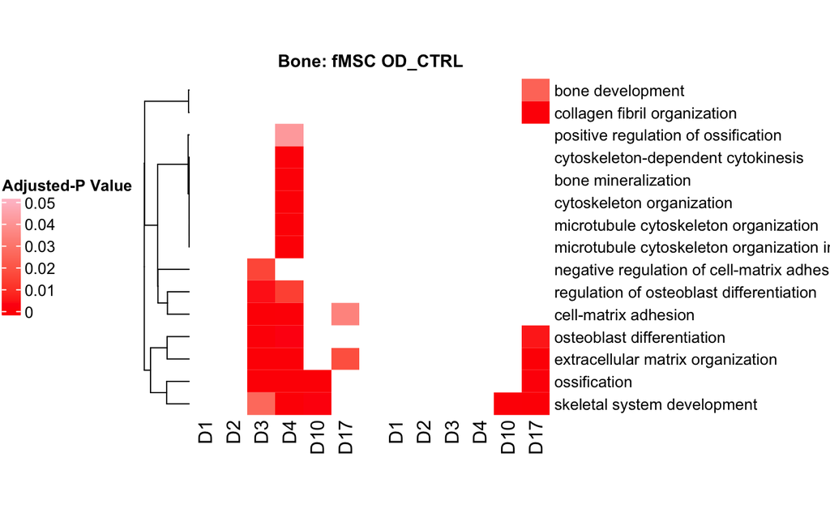

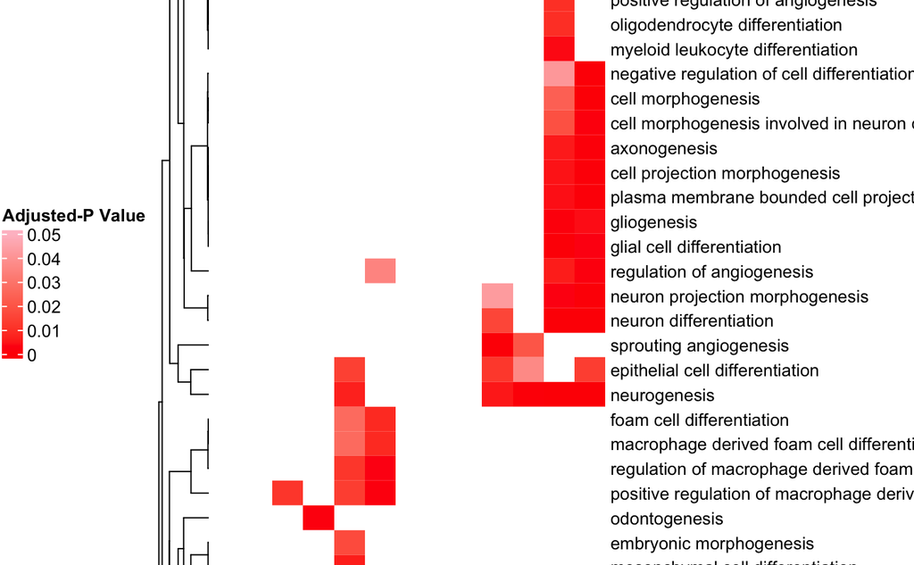

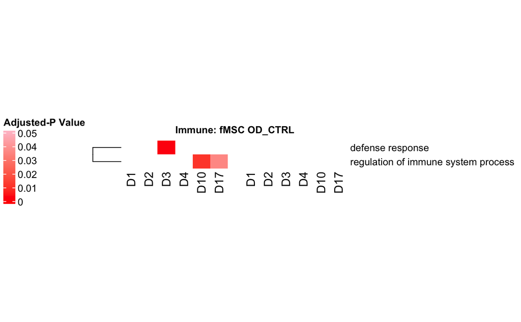

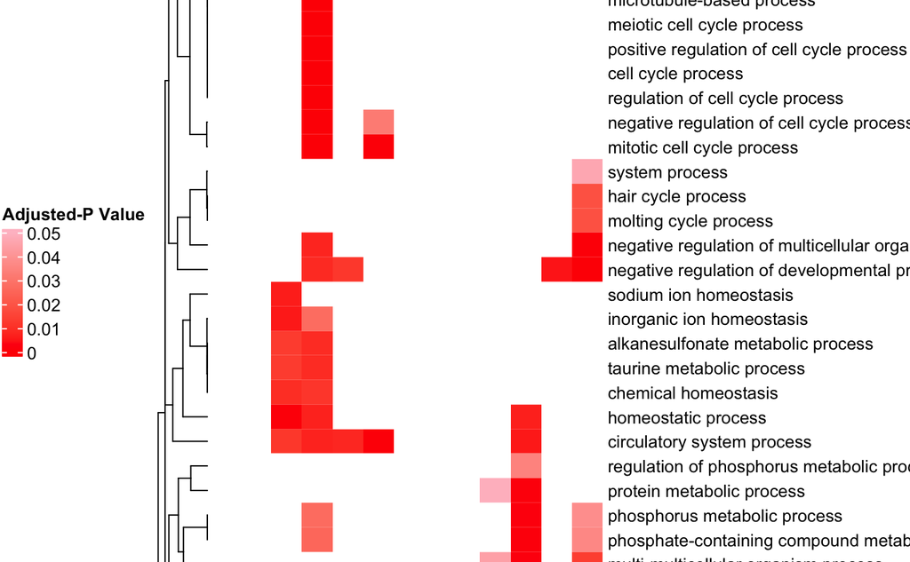

```r
# Theme label with an initial capital, e.g. "bone" -> "Bone".
theme_label <- function(th) paste0(toupper(substring(th, 1, 1)), substring(th, 2))

for (th in c("bone", "diff", "immune", "metabolism")) {
  Th <- theme_label(th)
  plot_theme_heatmap(
    GeneList  = themes[[th]],
    Matrix    = f.pair.gsea,        # block A: OD
    Matrix2   = f.pair.gsea.CTRL,   # block B: CTRL
    HmapTitle = paste0(Th, ": fMSC OD_CTRL"),
    block_labels = c("fMSC OD", "fMSC CTRL"),
    # filename typo "Enrichmnet" kept so existing figure references still match
    FileName  = paste0("fMSC OD_CTRL ", Th, " Pairwise Enrichmnet"),
    greyscale = FALSE)
}
```

## 6.2 fMSC OD vs fMSC CTRL (greyscale, for print)

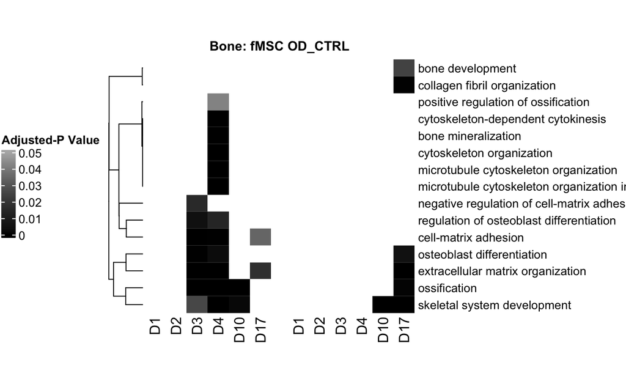

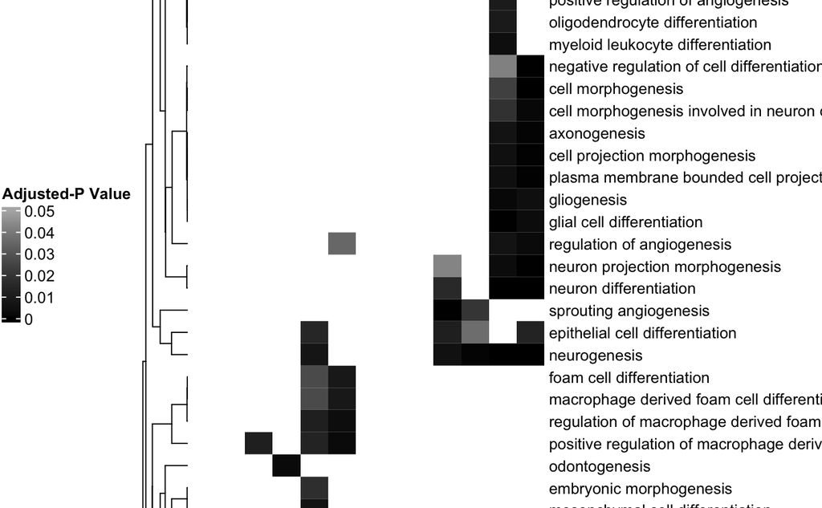

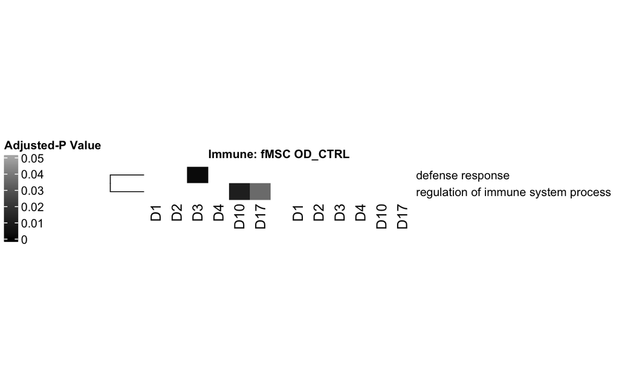

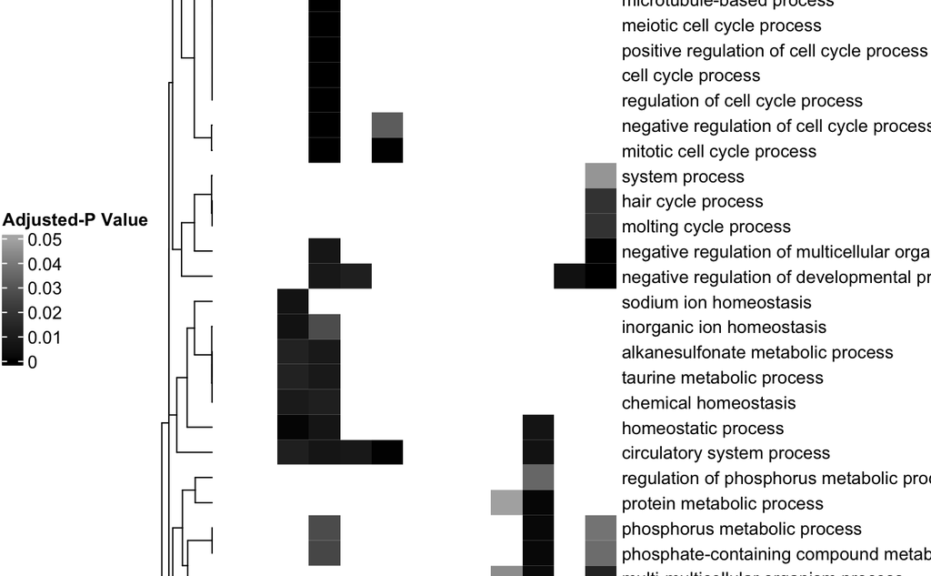

```r
for (th in c("bone", "diff", "immune", "metabolism")) {
  Th <- theme_label(th)
  plot_theme_heatmap(
    GeneList  = themes[[th]],
    Matrix    = f.pair.gsea,
    Matrix2   = f.pair.gsea.CTRL,
    HmapTitle = paste0(Th, ": fMSC OD_CTRL"),
    block_labels = c("fMSC OD", "fMSC CTRL"),
    FileName  = paste0("patent/fMSC OD_CTRL ", Th, " Pairwise Enrichmnet"),
    greyscale = TRUE)
}
```

## 6.3 fMSC OD vs aMSC OD (colour)

Same themes, but block B is now the adult OD enrichment: the comparison is fetal against adult rather than induced against control.

Note: the original notebook produced this comparison in greyscale only, so no colour version of these four figures existed. This chunk adds it, using the same destination convention as 6.1 (colour to the output root, greyscale to `patent/`).

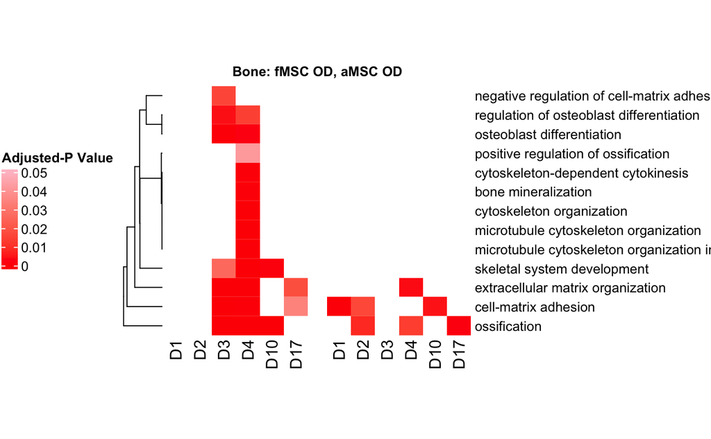

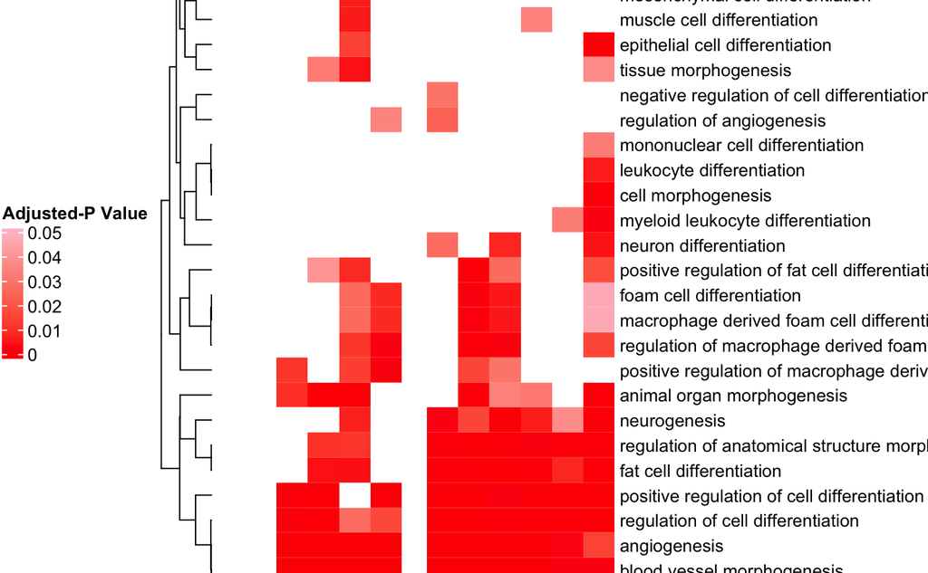

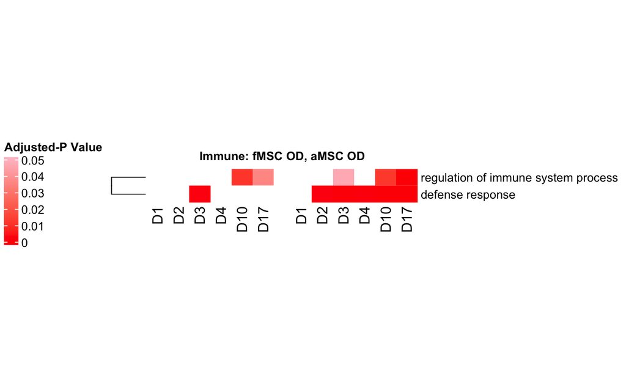

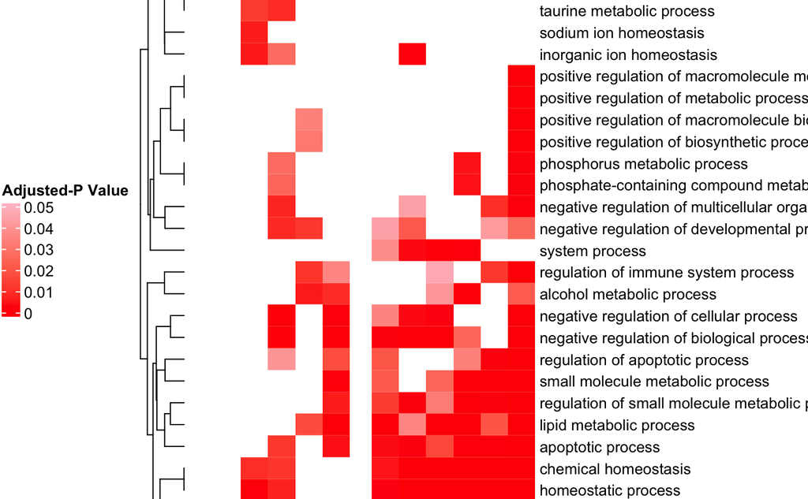

```r
for (th in c("bone", "diff", "immune", "metabolism")) {
  Th <- theme_label(th)
  plot_theme_heatmap(
    GeneList  = themes[[th]],
    Matrix    = f.pair.gsea,        # block A: fetal OD
    Matrix2   = a.pair.gsea,        # block B: adult OD
    HmapTitle = paste0(Th, ": fMSC OD, aMSC OD"),
    block_labels = c("fMSC OD", "aMSC OD"),
    FileName  = paste0("fMSC OD_aMSC OD ", Th, " Pairwise Enrichmnet"),
    greyscale = FALSE)
}
```

## 6.4 fMSC OD vs aMSC OD (greyscale, for print)

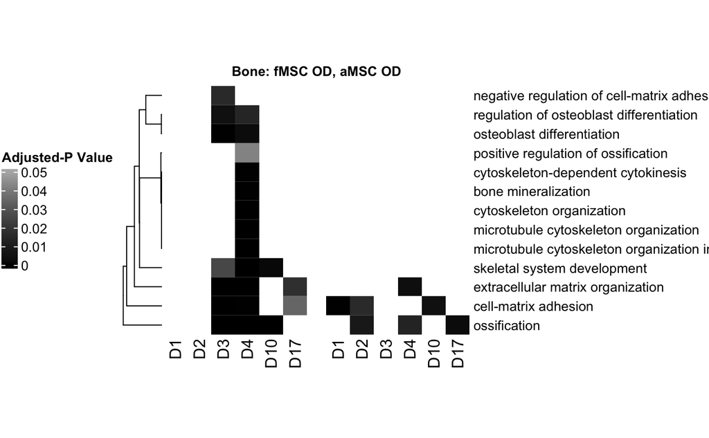

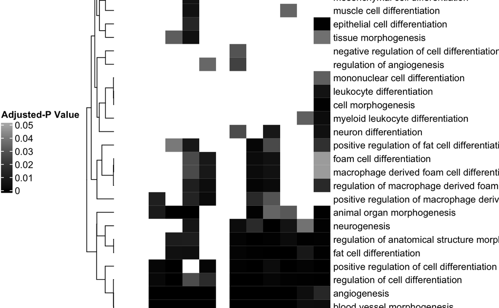

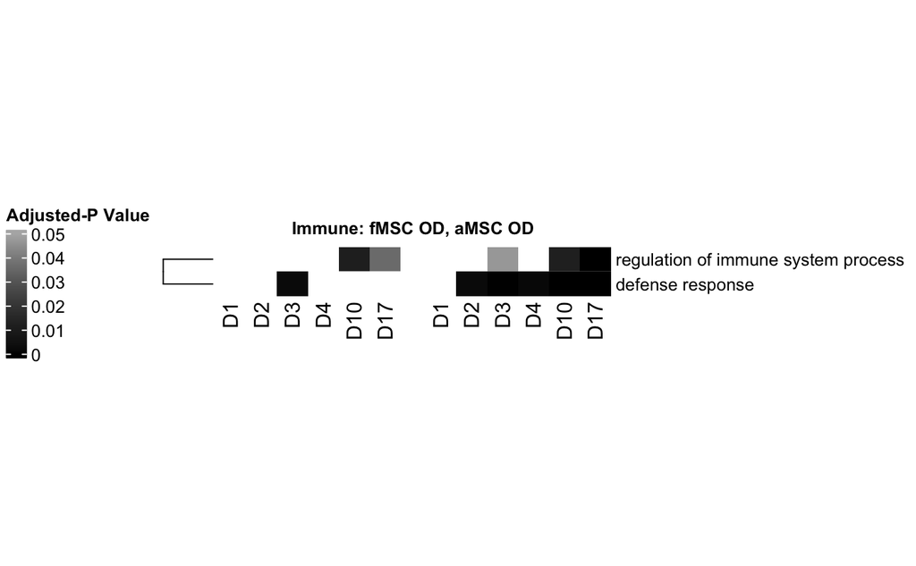

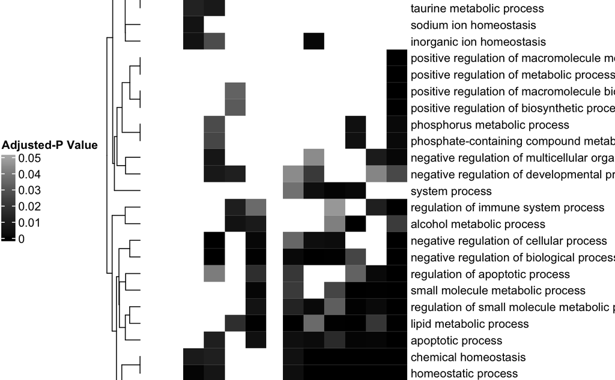

```r
for (th in c("bone", "diff", "immune", "metabolism")) {
  Th <- theme_label(th)
  plot_theme_heatmap(
    GeneList  = themes[[th]],
    Matrix    = f.pair.gsea,
    Matrix2   = a.pair.gsea,
    HmapTitle = paste0(Th, ": fMSC OD, aMSC OD"),
    block_labels = c("fMSC OD", "aMSC OD"),
    FileName  = paste0("patent/fMSC OD_aMSC OD ", Th, " Pairwise Enrichmnet"),
    greyscale = TRUE)
}
```